# Using Qualtrics

## Qualtrics

You can access Qualtrics by going to this URL and entering your UMD login information: https://umdsurvey.umd.edu/homepage/ui

# Step 1: Create a shared project

## Create a shared project

- Hit the “Create a new project” button on the bottom left-hand side of your screen.

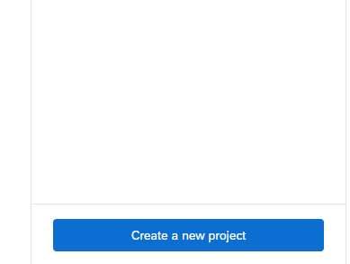

## Create a shared project

Select the option to create a survey from scratch and then hit “get started”

[figure not shown]

## Create a shared project

- Name your survey: SDSB340 Survey Fall 2026 Group [YOUR GROUP NUMBER]
- Then head back to the homepage: https://umdsurvey.umd.edu/homepage/ui

## Create a shared project

Find your project on the list of “Recently Visited” projects on the left hand side. Click the three dots and select “Collaborate” from the context menu.

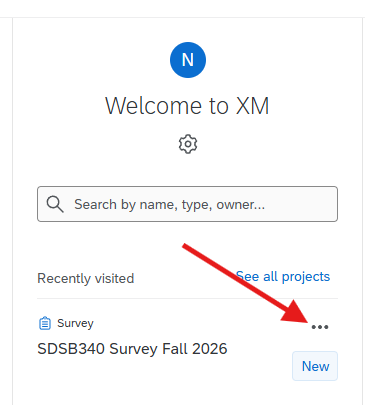

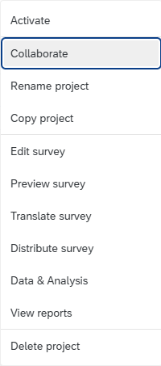

## Create a shared project

- Add UMD email addresses of your other group members.
- Add icoelho1@umd.edu and nlund@umd.edu as well.

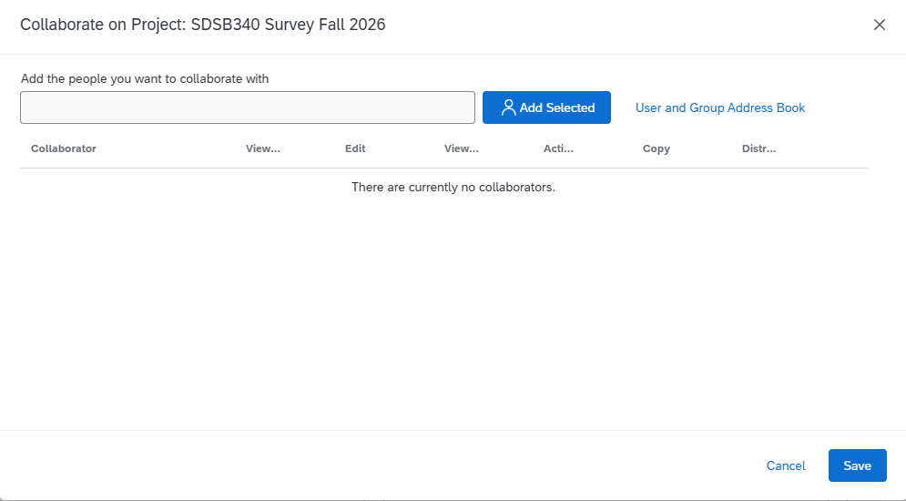

# Step 2: Add embedded data tracking

## Add embedded data tracking

Navigate back to your survey and hit the “Survey Flow” tab.

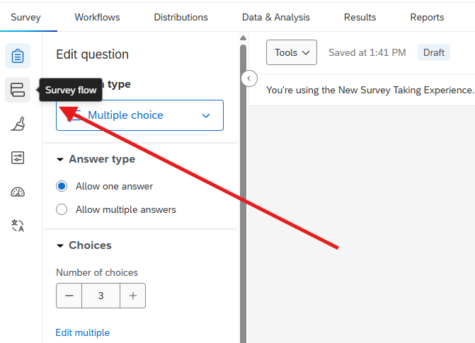

## Add embedded data tracking

Select “Add a New Element Here”

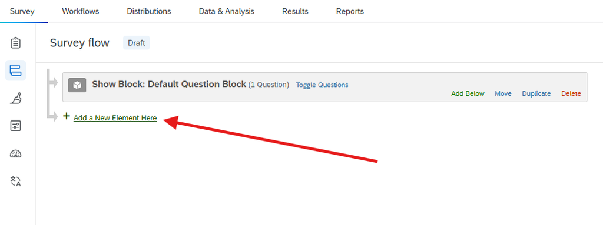

## Add embedded data tracking

Then hit the “Embedded Data” option.

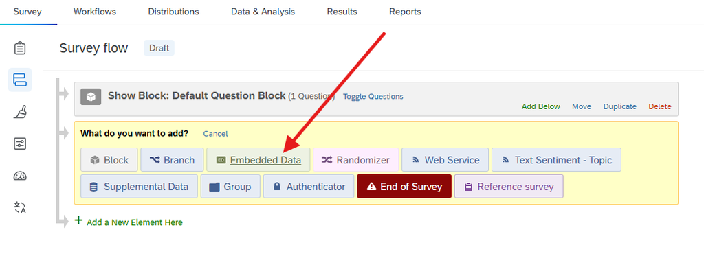

## Add embedded data tracking

Give the embedded data field the name “UID”

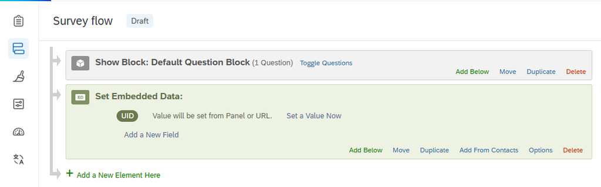

## Add embedded data tracking

Click the “Move” button and then drag the embedded data element to the top of the survey:

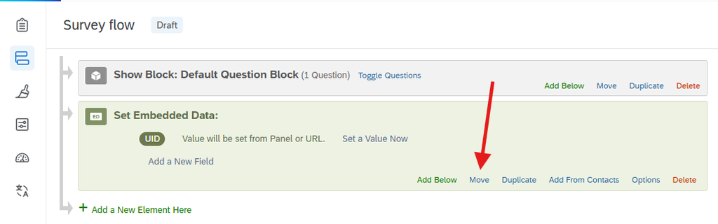

## Add embedded data tracking

When/if you add new flow elements, be sure they come in *after* the embedded data block! This should always be at the top.

Hit the “Apply” button in the bottom right to save your changes.

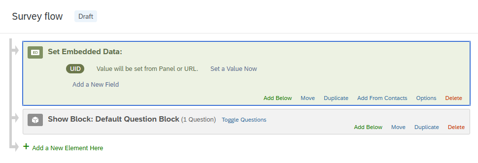

# Step 3: Create your survey

## Create your survey

Go back to the “Builder” tab and start creating your survey.

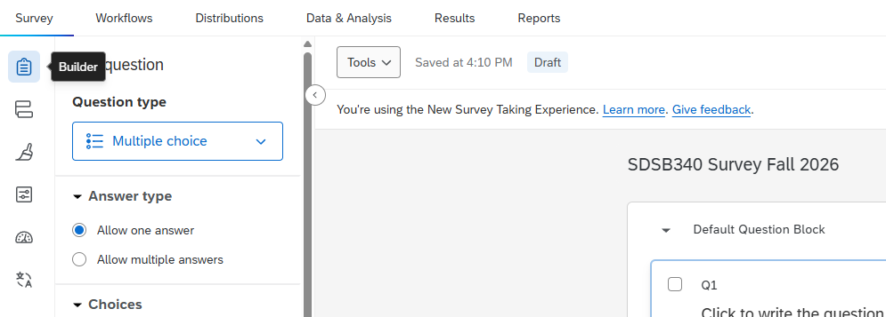

## Create your survey: tips

Feel free to use the “Import from library” button to get some pre-made demographic questions.

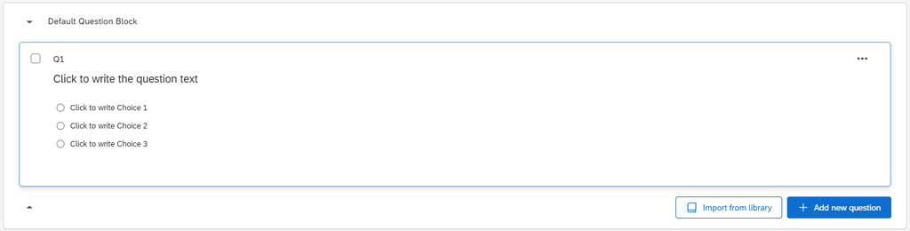

## Create your survey: tips

For multiple choice questions, you can select “Use suggested choices” button on the left hand side to get some common response formats like “agree/disagree”.

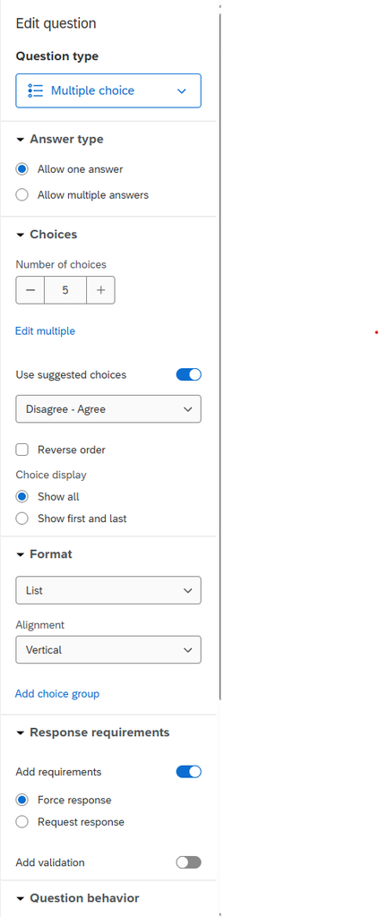

## Create your survey: tips

You can use the “recode values” option under “question behavior” to control the numeric values associated with different response categories. (this can simplify some of the recoding you have to do when you get responses back)

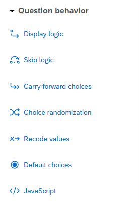

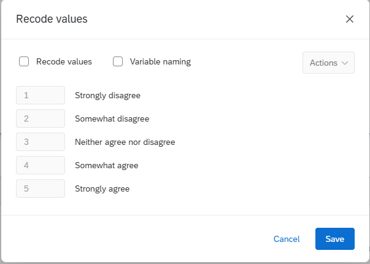

## Create your survey: tips

- Consider adding requested or forced response requirements.
- If you force a response, it’s usually a good idea to include a response option for “prefer not to answer”

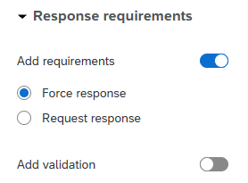

## Create your survey: tips

Use “display” and “skip logic” to make questions conditional. For instance: if you ask “what is your major?” then you might include skip logic to skip this question if a respondent tells you they’re not a student.

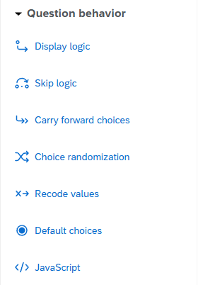

## Create your survey: tips

Select a question block and you will pull up some options for randomizing the ordering of questions within a block. You might consider using this if you’re concerned that question order will influence how people response.

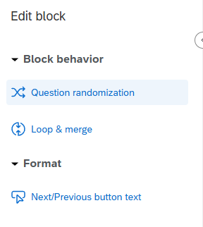

## Try out the stroop test

Here’s an example of some stuff you can do using Qualtrics with some custom Javascript:

https://umdsurvey.umd.edu/jfe/form/SV_7V52C9WqAG2TuoC